# Step by Step VMS Processing

Owen Liu

11/25/2019

```r
library(knitr)
library(here)
```

# Master VMS and Fish Ticket Processing Workflow

This document collates all individual steps of VMS/Fish Ticket processing. For testing, we will print a timer after each step.

## Choose Year to Process

This parameter will get passed through all processing steps

```r
alltime <- proc.time()
process_year <- 2012
```

# Step 1: Process Raw Fish Ticket Data

Date written: 11/2018 Updated: 11/2019 By: M. Fisher, O.R. Liu

## Purpose

This step pre-processes fish tickets from PacFIN for eventual matching to VMS records.

A few key aspects of the processing code:

1. You can filter out fish tickets with less than a minimum exvessel revenue or landed pounds. This could help remove personal catch, or catch used for monitoring purposes (like domoic acid testing for Dungeness crab). This only removes fish tickets based on total exvessel revenue or total landed pounds, not species-specific minimums.
2. When calculating species-specific landed pounds and exvessel revenue as separate columns, the code provides several options. It is possible to leave in all species listed on the fish ticket, which would create a different column for each species (around 300; *not recommended*). You can also select for species which you are particularly interested in. These species will each get their own column, and all other species will be grouped into “other”. If you want to break down the “other” category by gear type (i.e. other species caught by pot or trap gear, as is default here), then you can specify gear types in the `gear types` vector. Your choice of which species to highlight for this section *will not* impact the calculations of target species. In addition to reporting landed pounds and revenue for pre-determined species, you can also have a dynamic column that reports the same information for the target species of that trip.
3. Target species is calculated using the maximum landed pounds and exvessel revenue across all possible species caught. A target species will only be identified *if the target’s landed pounds / exvessel revenue are more than 10% greater than the next greatest value*. Otherwise, the target will be set to “none”. You will need to choose whether you want the target to be calculated using landed pounds v. exvessel revenue. +
4. All gear types listed for a specific trip are combined into the columns `gear_name_all` and `gear_code_all`, separated by a “/”. This prevents retention of duplicate fish tickets, but allows for later filtering.
5. If you want to reorder the columns in the data frame before writing it out, this can be done in the second to last code chunk, labeled (reorder_dataframe)
6. The code filters out any fish tickets with missing vessel identifiers (`VESSEL_NUM`)

## Set Up Workspace

Required packages

```r
library(tidyverse)
library(foreign)
library(qdapTools)
library(lubridate)
library(reshape2)
library(janitor)
library(here)
library(magrittr)

# ggplot theme
plot_theme <-   theme_minimal()+
  theme(text=element_text(family="sans",size=12,color="black"),
        legend.text = element_text(size=14),
        axis.title=element_text(family="sans",size=14,color="black"),
        axis.text=element_text(family="sans",size=8,color="black"),
        panel.grid.major = element_line(color="gray50",linetype=3))
theme_set(plot_theme)

rm(list=setdiff(ls(),c('process_year','alltime')))
```

Choose directories and set objects

```r
## which years of fish tickets are you interested in?
# process_year = c(2010,2011,2012)

## which species-specific revenue and lbs columns would you like? (static)
species_cols <- c("DCRB", "SABL", "LOBS", "SPRW")

## calculate an "other" category according to a certain gear type? If so, which gear?
gear_types <- c("FISH POT","FISH TRAP", "BOTTOMFISH POT", "TRAPS,
                SEATTLE TYPE (SABLEFISH)", "PRAWN TRAP", "SHELLFISH POT (NON-CRAB)")

## would you like target based on exvessel revenue or landed lbs?
target_metric <- "revenue"

## how much "more important" does your target need to be than the species with the second greatest catch? Expressed as a ratio. (default: target species catch / landings must be 10% greater than second greatest species catch / landings = 1.1)
target_cutoff <- 1.1

## do you want to report revenue and lbs for the given target species? (dynamic)
include_target <- TRUE
```

Set filtering-related objects[NOT CURRENTLY USED]

*part of the fish ticket processing adds columns to the output which specify the total amount and proportion of lbs / revenue attributed to certain species. all other species will be collapsed into an “other” column. use the following filtering options to select which species to retain. to leave in all species data, select `filter_type` = c(“none”). Note that this will not affect which species are used to determine TARGET for each trip.*

```r
# filter_type <- "none"    # choose any combination of "species", "pounds", "revenue" OR just "none"
# species_filter <- c()     # list species. if none, leave vector empty
# lbs_cutoff <- NA     # choose cutoff for landed lbs. if none, set as NA
# revenue_cutoff <- NA     # choose cutoff for exvessel revenue. if none, set as NA
```

## Read in Data

This should be a .csv file containing raw PacFIN data.

```r
rawdat <- read_csv(here::here('data','raw','fish tickets','2006_2016_compFT.csv'))
rawdat <- rawdat %>%
  filter(LANDING_YEAR %in%  process_year)
```

Check to make sure columns were in the correct format for reading. This will return the names of columns with parsing errors.

```r
problems(rawdat) %>% select(col) %>% distinct()
```

```
## # A tibble: 5 x 1
##   col
##   <chr>
## 1 VESSEL_TYPE_CODE
## 2 FISHER_LICENSE_NUM
## 3 FTID
## 4 TICKET_SOURCE_CODE
## 5 IFQ_ACCOUNT_NUM
```

```r
# The columns with parsing errors are usually from columns that we do not need anyway
```

## Edit existing columns

First, subset the raw data to include only the columns that are needed. Rename the columns that will be retained in the final processed data. The last three columns are used to calculate per-species / total revenue and landed weight, but will not ultimately be retained.

```r
rawdat.sub <- rawdat %>% select(FISH_TICKET_ID, PACFIN_PORT_CODE, PACFIN_GROUP_PORT_CODE, VESSEL_NUM, AGENCY_CODE, GEAR_CODE, GEAR_NAME, PACFIN_GROUP_GEAR_CODE, REMOVAL_TYPE_CODE, REMOVAL_TYPE_NAME, LANDING_DATE, LANDING_MONTH, LANDING_YEAR, PACFIN_SPECIES_CODE, LANDED_WEIGHT_LBS, EXVESSEL_REVENUE) %>%
# change some column names
  set_colnames(c("Rec_ID","pacfin_port_code", "port_group_code","drvid", "agency_code","gear_code", "gear_name", "gear_group", "removal_type_code", "removal_type_name", "date", "month", "year",
                          "PACFIN_SPECIES_CODE", "LANDED_WEIGHT_LBS", "EXVESSEL_REVENUE"))
```

Remove the columns where the vessel identifier (drvid) is either “UNKNOWN” or blank ("")

```r
rawdat.sub %<>%
  filter(drvid != "UNKNOWN") %>%
  filter(drvid != "")
```

Adjust gear group codes for some uncategorized gears

```r
rawdat.sub %<>%
  mutate(gear_group=case_when(
    gear_group=='MSC' & gear_name %in% c('SPEAR','DIVING - ABALONE IRON','DIVING - RAKE/HOOKS SEA URCHINS','DIVING', 'SHELLFISH DIVER') ~ 'DVG',
    gear_group=='MSC' & gear_name %in% c('UNKNOWN','UNKNOWN OR UNSPECIFIED GEAR') ~ 'USP',
    gear_group=='MSC' & gear_name %in% c('AQUACULTURE FARM','OYSTER FARM','CLAM FARM') ~ 'FRM',
    TRUE ~ gear_group
  ))
```

## Concatenate gear / catch information

Concatenate all species information for the fish ticket.

```r
all.species <- rawdat.sub %>%
  group_by(Rec_ID, removal_type_name) %>%
  summarise(species_code_all = ifelse(length(unique(PACFIN_SPECIES_CODE)) > 1, paste(unique(PACFIN_SPECIES_CODE), collapse="/"), as.character(unique(PACFIN_SPECIES_CODE))))
```

Concatenate the gear information for the fish ticket

```r
gear.info <- rawdat.sub %>%
  group_by(Rec_ID, removal_type_name) %>%
  summarise(gear_name_all = ifelse(length(unique(gear_name)) > 1, paste(unique(gear_name), collapse="/"), as.character(unique(gear_name))),
            gear_code_all = ifelse(length(unique(gear_name)) > 1, paste(unique(gear_code), collapse="/"), as.character(unique(gear_code))))
```

## Find Target Species

We need to define the target species for each landed ticket. We will do this by finding the species with the greatest landed revenue for each trip. Right now, each row of the data is a landing amount for a particular gear/ticket/species combo. We want to collapse these tickets in order to just have one row for each ticket, with an associated amount of landings for the TARGET species.

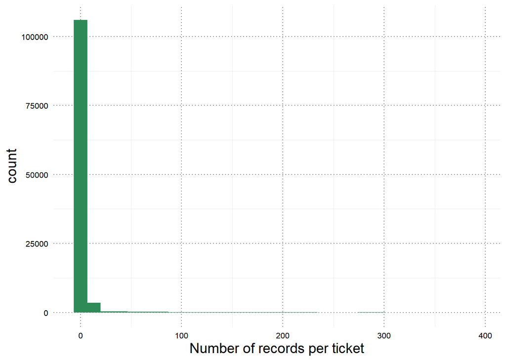

```r
rawdat.sub %>% count(Rec_ID) %>%
  ggplot(aes(n,..count..))+
  geom_histogram(fill="seagreen",bins=30)+
  labs(x="Number of records per ticket","kernel density")
```

Calculate landed pounds and revenue by species for each fish ticket. Then use these data to define proportions of pounds and revenue by species/ticket, in order to designate a “target” species for each fishing trip. We denote the target species for both revenue and pounds landed. If a ticket does not have a definitive target (classified as a proportion of landed pounds or revenue that is >10 percent more than the second-place species), denote “NONE” for the target.

```r
rawdat.w.targets <- rawdat.sub %>%
  distinct() %>%
  # Group by ticket, removal type, and species
  group_by(Rec_ID,removal_type_code,removal_type_name,PACFIN_SPECIES_CODE) %>%

  # calculate landed pounds and revenue by species
  summarise(spp_lbs=sum(LANDED_WEIGHT_LBS),
            spp_revenue=sum(EXVESSEL_REVENUE)) %>%
  ungroup() %>%

  # now, calculate total pounds per species across the entire ticket
  group_by(Rec_ID,PACFIN_SPECIES_CODE) %>%
  mutate(tot_lbs_spp=sum(spp_lbs),
         tot_revenue_spp=sum(spp_revenue)) %>%
  ungroup() %>%

  # using these species totals, calculate proportions of total catch belonging to each species
  # by lbs landed and revenue
  group_by(Rec_ID) %>%
  mutate(prop_lbs_spp=tot_lbs_spp/sum(tot_lbs_spp),
         prop_revenue_spp=tot_revenue_spp/sum(tot_revenue_spp)) %>%

  # finally, assign a TARGET to the trip, defined as the species with the
  # LARGEST proportion of revenue for that trip
  # If a species landed is not >10% more than the second species, target is NONE
  mutate(first_rev=dplyr::first(prop_revenue_spp,order_by = desc(prop_revenue_spp)),
         second_rev=dplyr::nth(prop_revenue_spp,n=2,order_by = desc(prop_revenue_spp)),
         first_rev_spp=dplyr::first(PACFIN_SPECIES_CODE,order_by= desc(prop_revenue_spp)),
         second_rev_spp=dplyr::nth(PACFIN_SPECIES_CODE,n=2,order_by= desc(prop_revenue_spp)),
         first_lbs=dplyr::first(prop_lbs_spp,order_by = desc(prop_lbs_spp)),
         second_lbs=dplyr::nth(prop_lbs_spp,2,order_by = desc(prop_lbs_spp)),
         first_lbs_spp=dplyr::first(PACFIN_SPECIES_CODE,order_by=desc(prop_lbs_spp)),
         second_lbs_spp=dplyr::nth(PACFIN_SPECIES_CODE,n=2,order_by= desc(prop_lbs_spp))) %>%

  # check if first is >10% more than second, for revenue and landed lbs
  # or, if first and second species are the same (i.e. for a ticket with both commercial and personal use catch)
  # if so, assign that species as TARGET

  mutate(TARGET_rev=ifelse(is.na(first_rev/second_rev)|(first_rev/second_rev)>=target_cutoff|first_rev_spp==second_rev_spp,first_rev_spp,"NONE"),
         TARGET_lbs=ifelse(is.na(first_lbs/second_lbs)|(first_lbs/second_lbs)>=target_cutoff|first_lbs_spp==second_lbs_spp,first_lbs_spp,"NONE")) %>%
  ungroup() %>%
  select(-(first_rev:second_lbs_spp))

# Add back in dates, vessel IDs, etc.
recID_attributes <- rawdat.sub %>%
  select(Rec_ID,PACFIN_SPECIES_CODE,pacfin_port_code,port_group_code,gear_code,gear_name,gear_group,drvid,agency_code,date,month,year)

rawdat.w.targets %<>%
  left_join(recID_attributes,by=c("Rec_ID","PACFIN_SPECIES_CODE"))

# add all species and gear types for each ticket
rawdat.w.targets %<>%
  left_join(all.species) %>%
  left_join(gear.info)
```

## Calculate “Other” Category

For each fish ticket, sum up an “Other” category based on the choice made in the beginning of the script (`gear_types`)

```r
dat_targets_other <- rawdat.w.targets %>%
  distinct() %>%
  group_by(Rec_ID) %>%
  # denote whether a record is in the Other category
  mutate(is_other=gear_name %in% gear_types) %>%

  # sum the other category for each ticket
  mutate(other_rev=sum(tot_revenue_spp[is_other]),
         other_lbs=sum(tot_lbs_spp[is_other]))
```

## Add Species-Specific Columns

Here we add some species-specific columns based on the choice made in the beginning of the script (`species_cols`).

```r
# Use pivoting to define pounds and revenue for each species of interest
RecID_spp_cols <- dat_targets_other %>%
  select(Rec_ID,PACFIN_SPECIES_CODE,tot_lbs_spp,tot_revenue_spp) %>%
  filter(PACFIN_SPECIES_CODE %in% species_cols) %>%
  distinct() %>%
  pivot_longer(tot_lbs_spp:tot_revenue_spp) %>%
  mutate(type=ifelse(str_detect(name,'lbs'),'lbs','revenue')) %>%
  select(-name) %>%
  group_by(Rec_ID) %>%
  # spread to create the columns
  pivot_wider(names_from=c(PACFIN_SPECIES_CODE,type),values_from = value,values_fill = list(value=0))

# add back to main data
dat_targets_other %<>%
  left_join(RecID_spp_cols)
```

## Add Trap/Pot/Ring designation

If the gear type is a trap or pot or ring, denote this

```r
dat_targets_other %<>%
  mutate(TRAP.OR.POT.OR.RING=str_detect(gear_name,"TRAP")|str_detect(gear_name,"POT")|str_detect(gear_name,"RING"))
```

## Format Dates

Change existing date columns to date objects and format.

```r
dat_targets_other %<>%
  mutate(date=as.Date(date,"%d-%b-%y")) %>%
  mutate(month=lubridate::month(date),
         month=month.name[month],
         year_mo=paste(year,lubridate::month(date),sep="_"),
         jdate=yday(date),
         year_jdate=paste(year,jdate,sep="_"),
         Week=week(date),
         year_Wk=ifelse(Week < 10, paste0(year,"_0",Week), paste0(year,"_",Week)))
```

## Duplicated Dates

We add two columns that denote how many tickets were submitted by a vessel in a given day. `n_tix` denotes the total number of tickets, whicle `n_nonpers_tix` denotes the total number of tickets NOT for personal use

```r
dat_out <- dat_targets_other %>%

  # boolean indicating whether a record is for personal use
  mutate(is_personal=removal_type_name=="PERSONAL USE") %>%

  # for each vessel and date
  group_by(drvid,date) %>%

  # calculate quantities of interest
  mutate(n_tix=n_distinct(Rec_ID),
         n_pers=n_distinct(Rec_ID[is_personal]),
         n_nonpers_tix=n_tix-n_pers) %>%
  select(-n_pers,-is_personal) %>%
  ungroup()
```

## Reorder Output

Clean up the output by reording the columns of interest

```r
dat_out %<>%
  select(-(spp_lbs:prop_revenue_spp),-is_other) %>%
  select(Rec_ID,pacfin_port_code,port_group_code,drvid,agency_code,removal_type_code,removal_type_name,gear_code_all,TRAP.OR.POT.OR.RING,date,month,year,year_mo,jdate,year_jdate,Week,year_Wk,contains("_lbs"),contains("_rev"),species_code_all,other_lbs,other_rev) %>%
  # the last distinct() removes records for which we no longer care about individual sub-trip species catches (we only care about catched of the focal species, plus total catch and TARGETs)
  distinct()
```

## Save

Save the data!

```r
yrs_of_data <- unique(dat_out$year)
for(y in 1:length(yrs_of_data)) {
 dat_out %>%
    filter(year==yrs_of_data[y]) %>%
    write_rds(here::here('data','processed','fish tickets',paste0(yrs_of_data[y],"fishtix",".rds",collapse="")))
}
# for(y in unique(rawdat$LANDING_YEAR)){
#   year.final.processdat <- filter(final.processdat, year == y )
#   write_csv(file = paste0(processdir, "fish tickets ", y, " processed_multispecies03.csv"), x = year.final.processdat, row.names = FALSE)
#   cat("wrote out file for ", y, "\n")
# }
```

```r
x<-proc.time()-alltime
```

**So far, this pipeline for 2012 VMS data has taken 1.94 minutes to run.**

# Step 2: Report Vessel Lengths

## Purpose

Calculate vessel lengths based on vessel registration data, and then add in a few columns to the fish ticket data providing vessel length for each ticket.

We use a decision tree for calculating vessel length from PacFIN data. The template allows for one year or multiple years of fish tickets to be run at the same time. To run the vessel length calculations for *all* vessels in the landings data, set option `dcrb_only` to `FALSE` in Setup and Options (this is the default).

Currently, the code writes out processed vessel length keys and combined vessel length/fish ticket landings data as `.rds` files. Code to write to `.csv` maintained but commented out.

Plotting of outputs is optional, indicated

## Methods Overview:

- Step 1: Pull the registration data up to two years prior to the fish ticket year (3 years total)
- Step 2: Remove any registration entries with vessels larger than 200 feet and smaller than 10 feet
- Step 3: Find the number of unique vessel lengths for all unique Vessel Number / Agency Code combinations.
- Step 4: Calculate final vessel length for all unique Vessel Number / Agency Code combinations
- If vessel length data was available for 2+ years and MAX_LENGTH < MIN_LENGTH + 10, then assume this reflects an actual increase or decrease in vessel size.Final vessel length is mean of the two most recent vessel lengths
- If vessel length data was available for only one year OR vessel length data was available for 2+ years, but MAX_LENGTH > MIN_LENGTH + 10. Pull registration data up to four years prior to the fish ticket year (5 years total). Then, if…
  1. One vessel length was recorded in 2+ years. Use this value as vessel length.
  2. Two different vessel lengths were recorded.
  3. MAX_LENGTH > 2 x MIN_LENGTH. <– this is probably a decimal point error that we would need to check manually to determine true length. Denote NA.
  2. MAX_LENGTH < 2 X MIN_LENGTH. <– Use the mode of these lengths
  3. Three or more different vessel lengths were recorded. Use the median of these lengths

### Script Includes:

1. Calculation of vessel lengths for X years of fish tickets.
2. Summary of calculation output: proportion of fishing vessels missing lengths (per year), distribution of vessel lengths (per year and overall), vessel length against the number of years vessel length was recorded (per year), and the frequency of the calculation types used (per year and overall).
3. Application of calculated vessel lengths to appropriate fish tickets.

Resources:

[PMSC Fleet Report](https://www.psmfc.org/efin/docs/fleetreport.pdf), esp Table 8 [PacFIN Column names key](https://pacfin.psmfc.org//wp-content/uploads/2016/06/PacFIN_Comprehensive_Fish_Tickets.pdf)

## Setup and Options

Load packages

```r
library(tidyverse)
library(here)
library(magrittr)
library(knitr)

# ggplot theme
plot_theme <-   theme_minimal()+
  theme(text=element_text(family="sans",size=12,color="black"),
        legend.text = element_text(size=14),
        axis.title=element_text(family="sans",size=14,color="black"),
        axis.text=element_text(family="sans",size=8,color="black"),
        panel.grid.major = element_line(color="gray50",linetype=3))
theme_set(plot_theme)


rm(list=setdiff(ls(),c('process_year','alltime')))
```

Source functions for vessel length calculations.

```r
source(here::here('process steps',"Report_Vessel_Length_processedtix_functions.R"))
```

Enter processing options: Year desired to be processed, whether to only process Dungeness vessels, and whether to plot outputs.

```r
# process_year <- c(2011)
dcrb_only <- FALSE
plot_output <- TRUE
```

## Vessel Permit Data

Load permits data for 2016-2017

```r
permits1 <- read_csv(here::here('data','raw','vessel registration','Vessel_Registrations_2016_2017.csv'),col_types='ddcddccdcccccdddcccccccddll')
```

Load permits data since 1981

```r
permits2 <- read_csv(here::here('data','raw','vessel registration','Vessel_Registrations_1981_2016.csv'),col_types='ddcddccdcccccdddcccccccddll')
```

Bind data frames

```r
permits <- bind_rows(permits1, permits2)
rm(permits1, permits2)
```

## Subset Permit Data

Choose columns of interest and subset the data frame

```r
pcols <- c("VESSEL_NUM", "AGENCY_CODE","REGISTRATION_YEAR","VESSEL_LENGTH", "LENGTH_TYPE_CODE")
pthin <- permits %>%  select(pcols)
```

Change all entries of `777` for vessel length to `NA` (based on recommendation from Blake Feist)

```r
pthin %<>%
  mutate(VESSEL_LENGTH=na_if(VESSEL_LENGTH,777))
```

Remove any vessel lengths greater than 200 or lower than 10. *Note - depending on the fishery, may want to change these cutoffs*

```r
pthin_length_filter <- pthin %>%
  filter(VESSEL_LENGTH < 200,VESSEL_LENGTH > 10)
```

## Vessels of Interest

Read in raw fish ticket `.rds` files for each year of interest to data frame “landings”. If option `dcrb_only` above is `TRUE`, filter to only vessels with positive revenue for Dungeness crab in the landings data.

```r
# import landings data
landings <- purrr::map(process_year, function(y){
  read_rds(here::here('data','processed','fish tickets',paste0(y,'fishtix.rds')))
}) %>%
  bind_rows()

# find relevant vessels (all vessels versus Dungeness vessels only)
vessels <- landings %>%
  filter(drvid != "UNKNOWN", drvid != "MISSING", drvid != "", !is.na(drvid)) %>%
  select(drvid, agency_code, year) %>%
  distinct()

if(dcrb_only){
  vessels <- landings %>%
    filter(drvid != "UNKNOWN", drvid != "MISSING", drvid != "", !is.na(drvid)) %>%
    filter(DCRB_revenue > 0) %>%
    select(drvid, agency_code, year) %>%
    distinct()
}
```

## Calculate Vessel Lengths

Initiate empty data frame for all vessel length data across years

```r
vessel_length_key_df <- tibble("drvid" = character(),
                               "agency_code" = character(),
                               "year" = numeric(),
                               "FINAL_LENGTH" = numeric(),
                               "TYPE_CALC" = character(),
                               "UNIQUE_LENGTHS" = numeric(),
                               "N_YEARS_LENGTH_RECORDED" = numeric(),
                               "HISTORIC_DATA" = character())
```

Do the calculation of vessel lengths.

```r
for(y in unique(vessels$year)){
  # take only the vessels fishing in year "y"
  year_vessels <- filter(vessels, year == y)

  # identify the years of regulation data to pull
  target_reg_years <- seq(y-2, y)

  # subset for target registration years and summarise permits for each vessel
  cat("Calculating 3yr summary statistics for vessels in ", y, "\n")
  pthin_sumstats <- pthin_length_filter %>%
    filter(REGISTRATION_YEAR %in% target_reg_years,!is.na(VESSEL_LENGTH)) %>%
    group_by(VESSEL_NUM, AGENCY_CODE) %>%
    arrange(desc(REGISTRATION_YEAR)) %>%
    summarise(n_lengths = length(VESSEL_LENGTH),
              n_unique = length(unique(VESSEL_LENGTH)),
              max_length = max(VESSEL_LENGTH),
              min_length = min(VESSEL_LENGTH),
              mean2yr = get2yrmean(x=VESSEL_LENGTH, years=REGISTRATION_YEAR)) %>%
    ungroup()

  # create empty vectors for this year
  final_vessel_lengths <- c()
  length_calc_vec <- c()
  n_unique_vec <- c()
  n_lengths_vec <- c()
  historic_vec <- c()
  processed <- 0

  cat("Calculating vessel lengths for fishing vessels in ", y, "...\n")
  # for each vessel fishing in this year #
  for(i in seq(1:length(year_vessels$drvid))){
    ## use the calc_length function (loaded from the "functions.R" file) to calculate vessel length
    tmp_vessel_length_info <- calc_length(permits=permits, vesseldat = year_vessels, lengthdat = pthin_length_filter, summarydat = pthin_sumstats, index = i)
    ## save the calc_length output to the appropriate position ("i") in the output vectors for this year
    n_lengths_vec[i] <- tmp_vessel_length_info[1] %>% as.numeric()
    n_unique_vec[i] <- tmp_vessel_length_info[2] %>% as.numeric()
    final_vessel_lengths[i] <- tmp_vessel_length_info[3] %>% as.numeric()
    length_calc_vec[i] <- tmp_vessel_length_info[4]
    ## if the vessel had to be calculated with historical data from over 5 years ago, a warning message will be saved in the calc_length output
    if(length(tmp_vessel_length_info) > 4){
      ### print the warning message
      print(tmp_vessel_length_info[5])
      ### save "Y" to the historic_vec for this year
      historic_vec[i] <- "Y"
    } else{ historic_vec[i] <- "N" }
    processed <- processed + 1
  }
  cat("Done processing", processed, "vessels for", y, "\n")
  # save allof the output vectors to a data frame for this year
  tmp_vessel_length_key_df <- tibble("drvid" = year_vessels$drvid,
                                     "agency_code" = year_vessels$agency_code,
                                     "year" = year_vessels$year,
                                     "FINAL_LENGTH" = final_vessel_lengths,
                                     "TYPE_CALC" = length_calc_vec,
                                     "UNIQUE_LENGTHS" = n_unique_vec,
                                     "N_YEARS_LENGTH_RECORDED" = n_lengths_vec,
                                     "HISTORIC_DATA" = historic_vec)
  ## bind this year's data frame to the end of the full data frame
  vessel_length_key_df <- bind_rows(vessel_length_key_df, tmp_vessel_length_key_df)
  cat("Wrote out", dim(tmp_vessel_length_key_df)[1], "lengths for", y, " to final data frame\n\n")
}
```

```
## Calculating 3yr summary statistics for vessels in  2012
## Calculating vessel lengths for fishing vessels in  2012 ...
## [1] "ERROR: Vessel OR66SN O COULD NOT BE FOUND IN PERMITS DATA BASE."
## [1] "ERROR: Vessel OR99YL O COULD NOT BE FOUND IN PERMITS DATA BASE."
## [1] "WARNING: Length for vessel WN4728LH O had to be calculated with data > 4 years prior to 2012"
## [1] "WARNING: Length for vessel WN4728LH O had to be calculated with data > 4 years prior to 2012"
## [1] "WARNING: Length for vessel 593326 O had to be calculated with data > 4 years prior to 2012"
## [1] "WARNING: Length for vessel 593326 O had to be calculated with data > 4 years prior to 2012"
## [1] "ERROR: Vessel OR77YM O COULD NOT BE FOUND IN PERMITS DATA BASE."
## [1] "ERROR: Vessel OR89UX O COULD NOT BE FOUND IN PERMITS DATA BASE."
## [1] "ERROR: Vessel WN0691RU O COULD NOT BE FOUND IN PERMITS DATA BASE."
## [1] "WARNING: Length for vessel WN5382GC O had to be calculated with data > 4 years prior to 2012"
## [1] "WARNING: Length for vessel WN5382GC O had to be calculated with data > 4 years prior to 2012"
## [1] "ERROR: Vessel WN8204RU O COULD NOT BE FOUND IN PERMITS DATA BASE."
## [1] "ERROR: Vessel 549293 O COULD NOT BE FOUND IN PERMITS DATA BASE."
```

[output cut: 63 more lines]

## Explore Vessel Lengths

How many fishing vessels WITH Vessel Numbers are missing calculated lengths?

```r
cat(sum(is.na(vessel_length_key_df$FINAL_LENGTH)), 'vessels with Vessel ID numbers are missing calculated lengths, or', sum(is.na(vessel_length_key_df$FINAL_LENGTH)) / length(vessel_length_key_df$FINAL_LENGTH)*100, 'percent.')
```

```
## 40 vessels with Vessel ID numbers are missing calculated lengths, or 0.9650181 percent.
```

```r
for(y in unique(vessel_length_key_df$year)){
  for(a in unique(vessel_length_key_df$agency_code)){
    tmp_dat <- vessel_length_key_df %>%
      filter(agency_code == a) %>%
      filter(year == y)
    missing <- sum(is.na(tmp_dat$FINAL_LENGTH))
    cat("Number", y, "Vessels Missing Vessel Lengths for", a, ":", missing, "\n")
    cat("Proportion:", missing/length(tmp_dat$FINAL_LENGTH), "\n\n")
  }
}
```

```
## Number 2012 Vessels Missing Vessel Lengths for O : 31
## Proportion: 0.02736099
##
## Number 2012 Vessels Missing Vessel Lengths for C : 4
## Proportion: 0.002111932
##
## Number 2012 Vessels Missing Vessel Lengths for W : 5
## Proportion: 0.004472272
```

```r
# ggplot(data=filter(vessel_length_key_df, !is.na(FINAL_LENGTH)), aes(x=as.numeric(FINAL_LENGTH),y=as.numeric(N_YEARS_LENGTH_RECORDED))) +
#   geom_point()+
#   facet_wrap(~year) +
#   xlab("Calculated Vessel Length") +
#   ylab("Number of Years Length Was Recorded") +
#   theme(axis.text.x = element_blank())
# Frequency table of number of years' records
vessel_length_key_df %>%
  count(N_YEARS_LENGTH_RECORDED) %>%
  kable(col.names = c("Number of Records","Number of Vessels"))
```

| Number of Records | Number of Vessels |
| --- | --- |
| 1 | 350 |
| 2 | 424 |
| 3 | 3319 |
| 4 | 6 |
| 5 | 2 |
| 6 | 2 |
| 18 | 1 |
| 26 | 1 |
| NA | 40 |

If plotting option above is `TRUE`, make some informative plots.

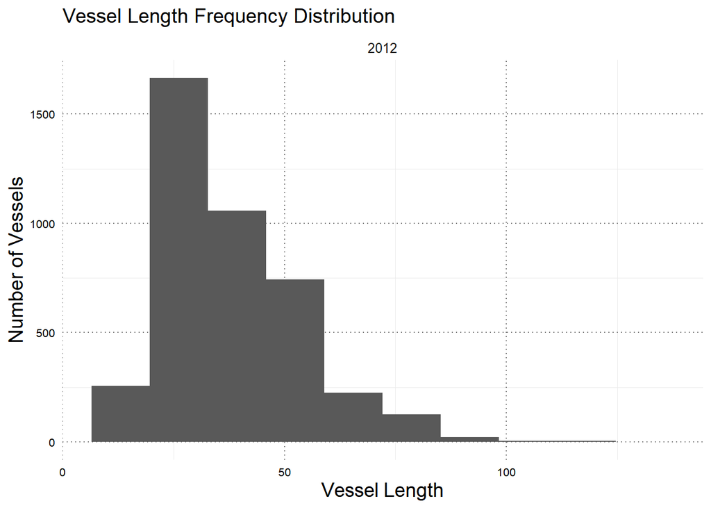

```r
if(plot_output){
  vessel_length_key_df %>%
    filter(!is.na(FINAL_LENGTH)) %>%
    ggplot(aes(as.numeric(FINAL_LENGTH))) +
      geom_histogram(bins=10) +
      facet_wrap(~year) +
      labs(x="Vessel Length",y="Number of Vessels",title="Vessel Length Frequency Distribution")
}
```

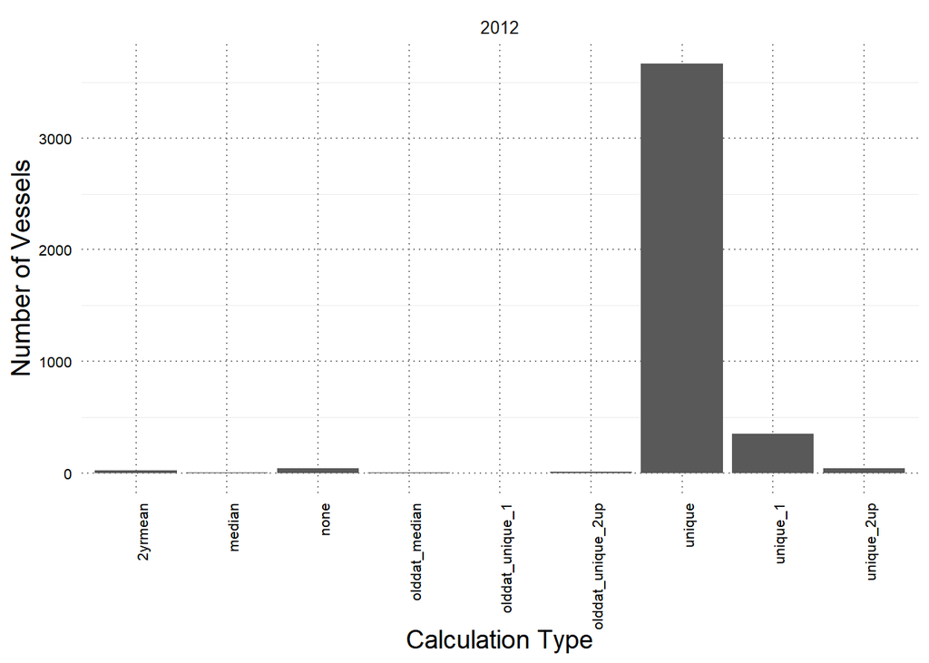

```r
if(plot_output){
  vessel_length_key_df %>%
    ggplot(aes(vessel_length_key_df$TYPE_CALC)) +
    geom_bar() +
    facet_wrap(~year) +
    labs(x="Calculation Type",y="Number of Vessels")+
    theme(axis.text.x = element_text(angle=90, hjust=1))
}
```

## Assess Missing Data for Fish Tickets

For each year, join vessel length data with landings. How many fish tickets are missing a vessel length, by agency? Non-specific.

```r
for(y in unique(vessel_length_key_df$year)){
  landings_subset <- landings %>%
    filter(year == y)
  dcrb_landings_length <- left_join(landings_subset, filter(vessel_length_key_df, year == y), by=c("drvid", "agency_code"))
  for(a in unique(dcrb_landings_length$agency_code)){
    tmp_dat <- filter(dcrb_landings_length, agency_code == a)
    missing <- sum(is.na(tmp_dat$FINAL_LENGTH))
    cat("Number of", y, "fish tickets missing vessel lengths for", a, ":", missing, "\n")
    cat("Proportion:", missing/length(tmp_dat$FINAL_LENGTH), "\n\n")
  }
}
```

```
## Number of 2012 fish tickets missing vessel lengths for O : 369
## Proportion: 0.0152947
##
## Number of 2012 fish tickets missing vessel lengths for C : 559
## Proportion: 0.008169529
##
## Number of 2012 fish tickets missing vessel lengths for W : 607
## Proportion: 0.02514186
```

## Save Results

Vessel lengths key

```r
for(y in unique(vessel_length_key_df$year)){
  key_subset <- vessel_length_key_df %>%
    filter(year == y)
  write_rds(key_subset,here::here('data','processed','vessel length keys',paste0("vessel_length_key_", y, ".rds")))
}
```

Landings matched to vessel lengths

```r
for(y in unique(vessel_length_key_df$year)){
  landings_subset <- landings %>%
    filter(year == y)
  vessel_length_key_df_subset <- vessel_length_key_df %>%
    filter(year==y) %>%
    select(-year)
  dcrb_landings_length <- left_join(landings_subset,vessel_length_key_df_subset, by=c("drvid", "agency_code"))
  write_rds(dcrb_landings_length,here::here('data','processed','fish tickets',paste0(y, "fishtix_vlengths.rds")))
}
# for(y in unique(vessel_length_key_df$year)){
#   landings_subset <- landings %>%
#     filter(year == y)
#   vessel_length_key_df_subset <- vessel_length_key_df %>%
#     filter(year==y) %>%
#     select(-year)
#   dcrb_landings_length <- left_join(landings_subset,vessel_length_key_df_subset, by=c("drvid", "agency_code"))
#   write.csv(file= paste0(fishtixdir, "processed_fishtickets_with_vlength_", y, ".csv"), x = dcrb_landings_length, row.names = FALSE)
# }
```

```r
x<-proc.time()-alltime
```

**So far, this pipeline for 2012 VMS data has taken 2.5 minutes to run.**

# Step 3: Process Raw VMS Data

## Purpose

This step in data processing further cleans raw VMS data. As of November 2019, we have been using raw VMS from the OLE. This may change in the near future, allowing us to obtain cleaner raw data from PacFIN.

The input VMS file should be partially pre-processed (cleaned, condensed) using a python script.

### Steps:

The following changes needed to be made for further processing:

1. Add in Cartesian geocoordinates (after checking for missing lat/lon)
2. Add in unique record numbers for each VMS record
3. Remove VMS records outside of a given latitude (assumed to be non-West Coast)
4. Add in the bathymetry layer
5. Remove high elevation points
6. Reorder columns

## Setup and Options

To process data, user can choose year and lat/lon bounds of VMS data points (currently set conservatively around US West Coast waters). Additionally, choose an upper bound for the bathymetry layer. Conservatively set at +100 ft., which should certainly retain all ocean areas.

```r
# process_year = 2012
lon_upper = -117 # if you do not want this filter, set to NA
lon_lower = -132 # if you do not want this filter, set to NA
lat_lower = 32 # if you do not want this filter, set to NA
lat_upper = 50 # if you do not want this filter, set to NA
bathy_upper = 100
```

## Read in Data

```r
vms_raw <- read_csv(here::here('data','raw','vms',paste0("VMS_all_data_", process_year, ".csv")),col_types='cddcddcc')

# convert UTCDATETIM to date-time class
vms_raw %<>%
  mutate(UTCDATETIM=parse_date_time(UTCDATETIM,"ymd HM"))
```

## Check for Missing Data

Are any records missing lat/lon?

```r
missing_lat <- sum(is.na(vms_raw$LATITUDE)); missing_lat
```

```
## [1] 3
```

```r
if(missing_lat > 0){
  View(vms_raw %>% filter(is.na(LATITUDE)))
}
```

**AFTER CHECKING ORIGINAL OLE FILE**, delete the missing record.

```r
vms_raw %<>% filter(!is.na(LATITUDE))
```

Some of the latitude measurements are listed as negatives (likely due to the parsing process). Check how many observations this affects, and then change them to positive.

```r
cat(sum(vms_raw$LATITUDE<0),'records have negative latitude.')
```

```
## 46712 records have negative latitude.
```

```r
vms_raw %<>% mutate(LATITUDE = ifelse(LATITUDE > 0, LATITUDE, LATITUDE*-1))
```

## Add Cartesian Coordinates and Assign VMS Record Numbers

Convert lat/long to cartesian geocoordinates for UTM zone 10.

```r
vms_coords <- vms_raw %>%
  # convert to simple features point object
  st_as_sf(coords=c("LONGITUDE","LATITUDE"),crs="+proj=longlat +datum=WGS84") %>%
  # project to UTM zone 10
  st_transform(crs = "+proj=utm +north +zone=10 +ellps=WGS84") %>%
  # extract XY coordinates
  st_coordinates()

# add to data frame
vms_raw %<>%
  mutate(X_COORD = vms_coords[,1],
         Y_COORD = vms_coords[,2])

# validate with back-conversion to lat/long for a random selection of 10 records
test_coords <- vms_raw %>%
  sample_n(10) %>%
  dplyr::select(LONGITUDE, LATITUDE, X_COORD,Y_COORD)

test_coordsLL <- test_coords %>%
  st_as_sf(coords=c("X_COORD","Y_COORD"),crs="+proj=utm +north +zone=10 +ellps=WGS84") %>%
  st_transform(crs="+proj=longlat +datum=WGS84") %>%
  st_coordinates()

# test whether coordinates are the same to 4 decimal places
all(round(test_coords[,c(1,2)],digits = 4)==round(test_coordsLL,digits=4))
```

```
## [1] TRUE
```

Add unique ID numbers for VMS records.

VMS_recno: select random integer values between X and Y, sampling without replacement. **CHECK PREVIOUS YEARS OF DATA TO MAKE SURE THERE ARE NO DUPLICATE RECORD NUMBERS**

```r
set.seed(0401) # set a RNG seed so that we have reproducibility if/when code is re-run
vms <- vms_raw %>%
  ungroup() %>%
  mutate(VMS_RECNO=row_number()+process_year*1e7) %>%
  mutate(VMS_RECNO=sample(VMS_RECNO))

# Did we make any duplicates for this year (by accident)?
!length(unique(vms$VMS_RECNO))==nrow(vms)
```

```
## [1] FALSE
```

```r
# Nope, all VMS_RECNO unique
```

## Remove Out-of-Bounds Records

This will delete records above the US-Canadian border (`lat_upper`) and below the US-Mexican border (`lat_lower`).

```r
dim(vms)
```

```
## [1] 6547310      11
```

```r
if(!is.na(lat_upper)){
  vms <- filter(vms, LATITUDE < lat_upper)
}
if(!is.na(lat_lower)){
  vms <- filter(vms, LATITUDE > lat_lower)
}
dim(vms)
```

```
## [1] 5861191      11
```

This will delete records far out to sea, or inland.

```r
dim(vms)
```

```
## [1] 5861191      11
```

```r
if(!is.na(lon_upper)){
  vms <- filter(vms, LONGITUDE < lon_upper)
}
if(!is.na(lon_lower)){
  vms <- filter(vms, LONGITUDE > lon_lower)
}
dim(vms)
```

```
## [1] 5814712      11
```

## Remove Duplicate Records

Duplicates are any VMS records with the same: UTCDATETIM, LATITUDE, LONGITUDE, VESSEL_NAM, DOCNUM.

Create data frame where duplicated record (second record) is removed.

```r
dim(vms)
```

```
## [1] 5814712      11
```

```r
tm <- proc.time()
vms_nodup <- vms %>%
  distinct(UTCDATETIM,LATITUDE,LONGITUDE,VESSEL_NAM,DOCNUM,.keep_all = TRUE)
proc.time()-tm
```

```
##    user  system elapsed
##    6.74    0.08    6.83
```

```r
# old version kept for checking efficiency/time
# tm <- proc.time()
# vms_nodup <- vms[!duplicated(vms[,c("UTCDATETIM","LATITUDE", "LONGITUDE", "VESSEL_NAM", "DOCNUM")]),]
# proc.time()-tm
# dim(vms_nodup)

# with addcount (pretty slow)
# tm <- proc.time()
# vms_nodup2 <- vms %>%
#   add_count(UTCDATETIM,LATITUDE,LONGITUDE,VESSEL_NAM,DOCNUM) %>%
#   filter(n==1)
# proc.time()-tm

# with group_indices
# tm <- proc.time()
# vms_nodup3 <- vms %>%
#   mutate(dupe_id=group_indices(.,UTCDATETIM,LATITUDE,LONGITUDE,VESSEL_NAM,DOCNUM)) %>%
#   distinct(dupe_id,.keep_all = TRUE)
# proc.time()-tm

cat("Proportion of VMS records removed for being true duplicate records:", 1-nrow(vms_nodup)/nrow(vms))
```

```
## Proportion of VMS records removed for being true duplicate records: 0.03377588
```

Save the duplicate entries to a file, to understand what data is being removed!

```r
# with janitor::get_dupes
tm <- proc.time()
vms_dupes <- vms %>%
  get_dupes(UTCDATETIM,LATITUDE,LONGITUDE,VESSEL_NAM,DOCNUM) %>%
  arrange(DOCNUM, UTCDATETIM) %>%
  dplyr::select(dupe_count,everything())
proc.time()-tm
```

```
##    user  system elapsed
##   35.80    2.11   38.00
```

```r
write_rds(vms_dupes, here::here('data','processed','vms',paste0(process_year, "_duplicates_only.rds")))
```

## Add Bathymetry

Read in the bathymetry SpatialGridDataFrame object

```r
bathy.grid <- read_rds(here::here('data','raw','vms_composite_bath_spGrid.RDS'))
```

Get bathymetry at VMS data points

```r
# tm <- proc.time()
vms_sp <- vms_nodup
coordinates(vms_sp) <- c("LONGITUDE", "LATITUDE")
proj4string(vms_sp)<-proj4string(bathy.grid) <- CRS("+init=epsg:4326") # WGS 84
bathy.points <- over(vms_sp, bathy.grid)$vms_composite_bath
# proc.time()-tm

vms_nodup <- mutate(vms_nodup, NGDC_M = bathy.points)
```

Remove high elevation bathymetry.

```r
vms_nodup_bathy <- vms_nodup %<>% filter(NGDC_M < bathy_upper)

cat('Filtering out records greater than',bathy_upper,'meters in elevation resulted in the removal of',nrow(vms_nodup)-nrow(vms_nodup_bathy),'records (',(nrow(vms_nodup)-nrow(vms_nodup_bathy))/nrow(vms_nodup)*100,'percent ).')
```

```
## Filtering out records greater than 100 meters in elevation resulted in the removal of 0 records ( 0 percent ).
```

## View Output

Plot points. We plot a subset of 100 thousand VMS records to make plotting time reasonable.

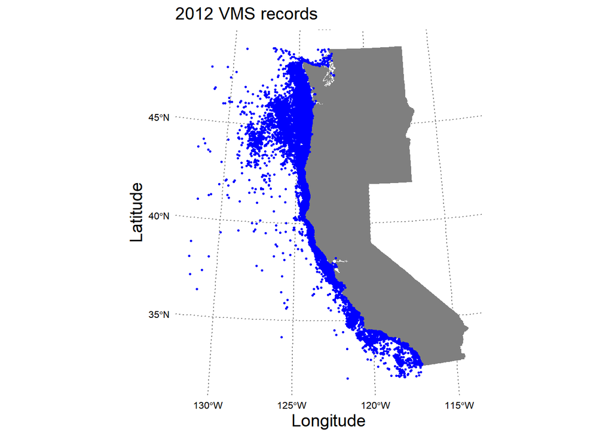

```r
vms_sf <- vms_nodup %>% st_as_sf(coords=c("X_COORD","Y_COORD"),crs = "+proj=utm +north +zone=10 +ellps=WGS84")

# Plotting takes a long time
# Try with a subset of 100k points
vms_sf_sample <- vms_sf %>%
  sample_n(100000) %>%
  filter(NGDC_M>-100000)

# coastline
coaststates <- ne_states(country='United States of America',returnclass = 'sf') %>%
  filter(name %in% c('California','Oregon','Washington')) %>%
  st_transform(st_crs(vms_sf))

ggplot()+
  geom_sf(data=coaststates,fill='gray50',col=NA)+
  geom_sf(data=vms_sf_sample,size=0.5,col='blue')+
  labs(x='Longitude',y='Latitude',title=paste0(process_year," VMS records"))
```

## Organize Output

```r
vms_ordered <- vms_nodup_bathy %>%
  dplyr::select(UTCDATETIM,LATITUDE,LONGITUDE,NGDC_M,VESSEL_NAM,AVG_SPEED,AVG_COURSE,DOCNUM,DECLARATIO,X_COORD,Y_COORD,VMS_RECNO)
```

## Save Results

```r
write_rds(vms_ordered,here::here('data','processed','vms',paste0(process_year,'_vms_clean.rds')))
```

Optionally, we can save as a .dbf. This chunk is currently turned off (`eval=FALSE`).

```r
vms_dbf <- vms_ordered

vms_dbf$UTCDATETIM <- as.character(vms_dbf$UTCDATETIM)
vms_dbf <- as.data.frame(vms_dbf)

# write
library(foreign)
write.dbf(dataframe=vms_dbf, here::here('data','processed','vms',paste0(process_year,'_vms_clean.dbf')), factor2char=TRUE)
```

```r
x<-proc.time()-alltime
```

**So far, this pipeline for 2012 VMS data has taken 6.26 minutes to run.**

# Step 5: Match VMS and Fish Ticket Data

## Purpose

This portion of the data processing matches the cleaned PacFIN fish tickets to the cleaned VMS data. We match the two datasets together using unique vessel identification numbers that are common to both datasets. We define a fishing “trip” as the collection of VMS observations directly preceding a landed fish ticket. Hence, all of the VMS pings that occur between two tickets are considered part of the latter ticket’s trip. We enforce a 7-day “lookback window” (S. Jardine, *pers. comm.*) such that if there are more than 7 days [an option that can be changed] between successive tickets for the same vessel, we only include data for those 7 days.

Later, the data are filtered and cleaned for depth, unrealistic speeds between pings, and corrected for multiple-ticket days.

## Setup and Data Import

Choose year to process

```r
# process_year <- 2012
```

Load fish ticket data (processed), including the last month of the previous year (for handling trips spanning January 1st of the current year)

```r
fishtix <- read_rds(here::here('data','processed','fish tickets',paste0(process_year,'fishtix.rds')))

if(process_year>2009){
  fishtix_prev <- read_rds(here::here('data','processed','fish tickets',paste0(process_year-1,'fishtix.rds'))) %>%
    filter(month(date)==max(month(date)))
  fishtix <- bind_rows(fishtix_prev,fishtix)
  rm(fishtix_prev)
}
```

Load VMS data, including the last month of the previous year (for handling trips spanning January 1st of the current year)

```r
vms <- read_rds(here::here('data','processed','vms',paste0(process_year,'_vms_clean.rds')))

if(process_year>2009){
  vms_prev <- read_rds(here::here('data','processed','vms',paste0(process_year-1,'_vms_clean.rds'))) %>%
    filter(month(UTCDATETIM)==max(month(UTCDATETIM)))
  vms <- bind_rows(vms_prev,vms)
  rm(vms_prev)
}
```

## Prep VMS Data for Matching

### Add West Coast Dates

PacFIN reports in west coast time, so create two columns with date/time in Pacific time zone

```r
vms %<>%
  # with time (hour, minute)
  mutate(westcoastdate = with_tz(UTCDATETIM, tzone = "America/Los_Angeles")) %>%
  # without time
  mutate(westcoastdate_notime = as_date(westcoastdate))
```

### Define Lookback Window and Begin/End Dates

Save the dates that serve as the beginning and end of that year’s data

```r
year_begin <- ymd(paste0(process_year,"-01-01"), tz= "America/Los_Angeles")
year_end <- ymd(paste0(process_year,"-12-31"), tz= "America/Los_Angeles")
```

Create lookback object. Here is where the lookback window duration can be changed. Default is 7 days.

```r
lookback_window <- 7

if(process_year == 2009){
  lookback_begin <- year_begin
} else{
  lookback_begin <- year_begin - days(lookback_window)
}
```

## Prep Fish Ticket Data for Matching

Truncate fish ticket data to match VMS year, with the lookback window where appropriate. This should prevent fish tickets from the previous year being assigned the same VMS data points.

```r
fishtix %<>%
  filter(date >= lookback_begin & date <= year_end) %>%

  #remove unneeded date columns
  select(Rec_ID:date,TARGET_lbs:species_code_all)
```

Add begin and end dates for each ticket to use in VMS matching. These define the windows of time in which we “search” for matching VMS pings. We also add a column for trip duration in days, for use in QA later.

```r
ptm <- proc.time()
fishtix %<>%

  # group by vessel
  group_by(drvid) %>%

  #add month
  mutate(month=month(date)) %>%

  # add a time for the end of day
  mutate(end = ymd_hms(paste(date, "23:59:59"),tz= "America/Los_Angeles")) %>%
  arrange(date) %>%

  # find the ticket BEFORE each ticket and note its time. Instead of creating NAs for the first ticket of the year for each vessel, assign a default value of January 1st. (CAN CHANGE THIS LATER, but for now allows us to use the first ticket of the year for each vessel)
  mutate(prev_ticket_dttm=lag(end,1,default=ymd_hms(paste0(process_year,"-01-01", " 23:59:59"),tz= "America/Los_Angeles"))) %>%

  # add lookback window
  mutate(lookback_dttm=end-days(lookback_window)) %>%

  # choose "begin" date for each ticket as the LATEST in time between previous ticket date and lookback date
  mutate(begin=ifelse(lookback_dttm>prev_ticket_dttm,lookback_dttm,prev_ticket_dttm) %>% as_datetime(tz= "America/Los_Angeles")) %>%

  # add trip duration
  mutate(trip_dur=interval(begin,end)) %>% mutate(trip_dur=time_length(trip_dur,"days")) %>%
  # select(-prev_ticket_dttm,-lookback_dttm) %>%

  ungroup()
x<-proc.time()-ptm
cat('Defining lookback window for all data took',x[3]/60,'minutes to run.')
```

```
## Defining lookback window for all data took 0.8596667 minutes to run.
```

## Match VMS to Fish Tickets

Here is where we do the actual matching of VMS data to fish tickets. Matching is done by vessel ID number and time, which are recorded in both datasets. We first join all VMS data for each vessel, then filter such that only the records within the appropriate window of time for each ticket (defined in the previous step) are retained.

```r
ptm <- proc.time()

join_vms_fishtix <- function(mth){

  tmptix <- fishtix %>%
    filter(month==mth)

  tmptix %>%
    # Left-join the VMS data by Vessel ID (drvid/DOCNUM)
    left_join(vms,by=c('drvid'='DOCNUM')) %>%

    # filter the VMS data such that the data for each trip is correctly truncated to fall within the lookback window.
    # If any tickets did NOT match VMS data, they will not have associated dates from VMS.
    # We retain these, and then produce a boolean indicator denoting that they did not match.

    filter((westcoastdate >= begin & westcoastdate <= end)| is.na(westcoastdate)) %>%
    mutate(has_vms=ifelse(is.na(westcoastdate),0,1)) %>%
    ungroup()
}

fishtix_vms <- purrr::map_df(unique(fishtix$month),~join_vms_fishtix(.)) %>%
  # finally, filter the edge case such that we remove trips ENDING before January 1st.
  # this will retain the VMS records that are before Jan 1 for any trips ending on or after Jan 1
    filter(year(date)==process_year)


## Join vms to fishtix
# fishtix_vms <- fishtix %>%
#
#   # Left-join the VMS data by Vessel ID (drvid/DOCNUM)
#   left_join(vms,by=c('drvid'='DOCNUM')) %>%
#
#   # filter the VMS data such that the data for each trip is correctly truncated to fall within the lookback window.
#   # If any tickets did NOT match VMS data, they will not have associated dates from VMS.
#   # We retain these, and then produce a boolean indicator denoting that they did not match.
#
#   filter((westcoastdate >= begin & westcoastdate <= end)| is.na(westcoastdate)) %>%
#   mutate(has_vms=ifelse(is.na(westcoastdate),0,1)) %>%
#   ungroup()
#
x<-proc.time()-ptm
cat('Joining VMS data and filtering took',x[3]/60,'minutes to run for',process_year)
```

```
## Joining VMS data and filtering took 1.565833 minutes to run for 2012
```

```r
# some checks
x <- fishtix_vms %>% filter(end<="2012-01-01 23:59:59 PST")
```

## Visualize Matching Results

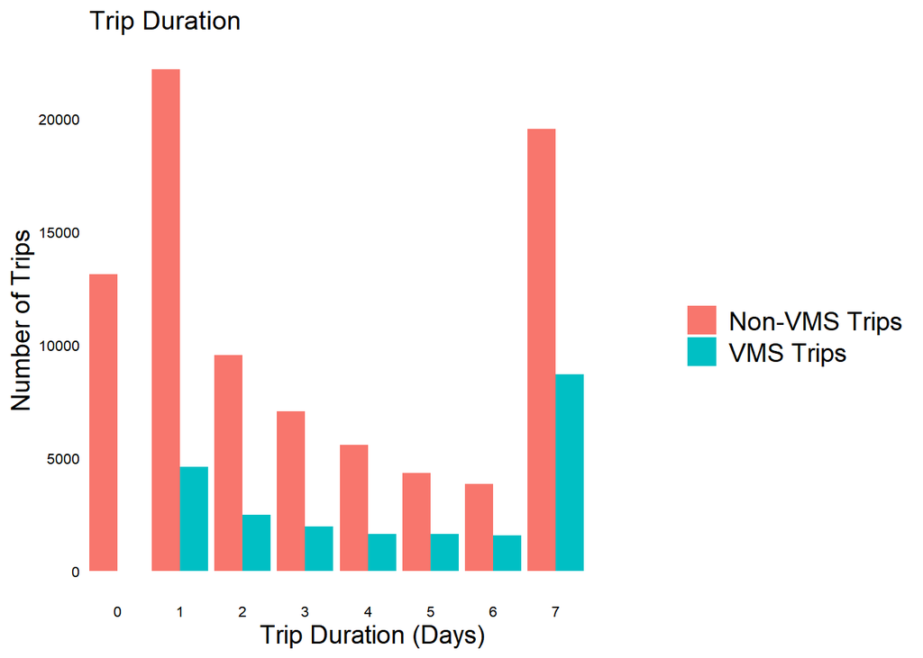

```r
# How long are trips?
fishtix_vms %>%
  select(Rec_ID,trip_dur,has_vms) %>%
  mutate(trip_dur=as.integer(trip_dur)) %>%
  distinct() %>%
  ungroup() %>%
  mutate(has_vms=ifelse(has_vms,"VMS Trips","Non-VMS Trips")) %>%
  ggplot(aes(trip_dur,fill=has_vms))+
  geom_bar(position = 'dodge')+
  scale_x_discrete(limits=seq(0,7,by=1))+
  labs(x="Trip Duration (Days)",y="Number of Trips",title="Trip Duration",fill="")
```

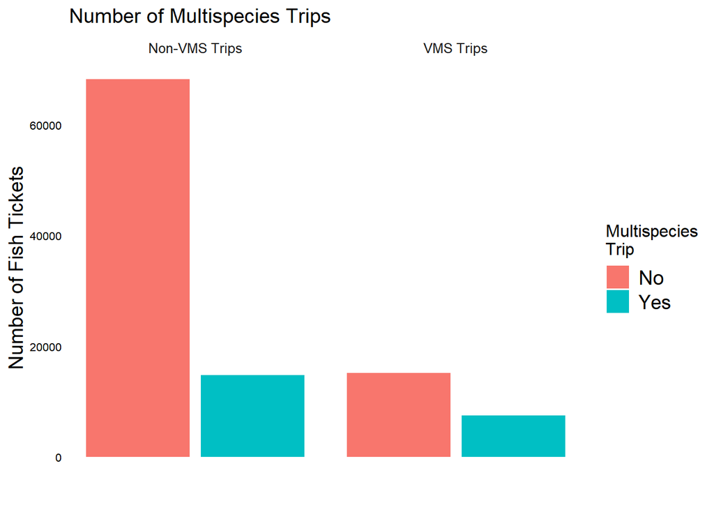

```r
# Count how many trips have multiple species (measured as multiple targets)
fishtix_vms %<>% mutate(multispecies=ifelse(nchar(species_code_all)>4,1,0))

fishtix_vms %>%
  select(Rec_ID,multispecies,has_vms) %>%
  distinct() %>%
  mutate(has_vms=ifelse(has_vms,"VMS Trips","Non-VMS Trips")) %>%
  ggplot(aes(factor(multispecies),fill=factor(multispecies)))+
  scale_fill_discrete(labels=c('No',"Yes"))+
  geom_bar()+
  facet_wrap(~has_vms)+
  labs(x="",y="Number of Fish Tickets",title="Number of Multispecies Trips",fill="Multispecies\nTrip")+
  theme(axis.text.x = element_blank())
```

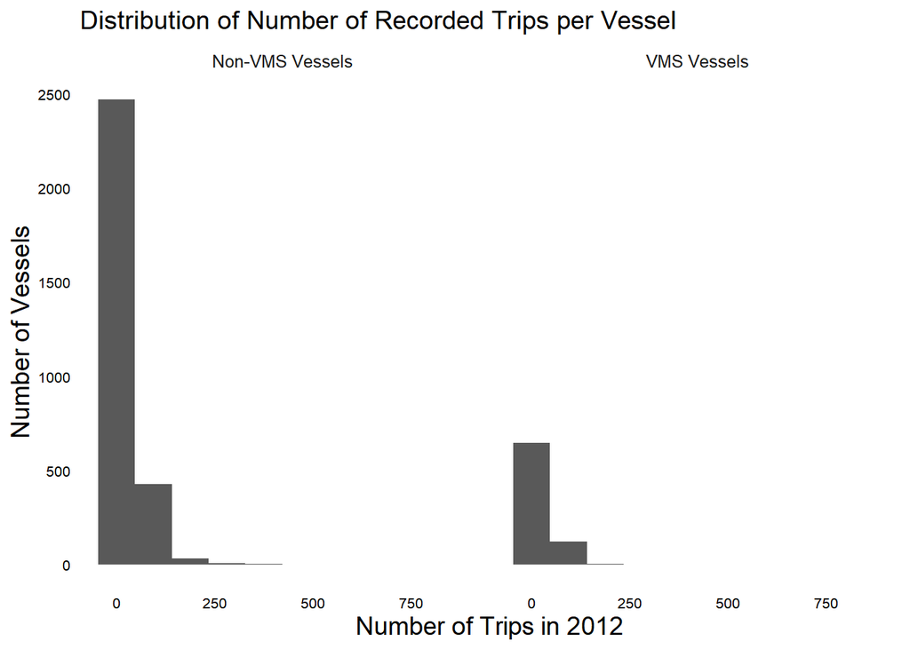

```r
# Distribution of number of trips per vessel, VMS vs. non-VMS records
fishtix_vms %>%
  group_by(drvid,has_vms) %>%
  summarise(ntix=length(unique(Rec_ID))) %>%
  ungroup() %>%
  mutate(has_vms=ifelse(has_vms,"VMS Vessels","Non-VMS Vessels")) %>%
  ggplot(aes(ntix,..count..))+
  geom_histogram(bins=10)+
  facet_wrap(~has_vms)+
  labs(x=paste("Number of Trips in",process_year),y="Number of Vessels",title="Distribution of Number of Recorded Trips per Vessel")
```

## Save Results

Save a version that has all fish ticket data, including records with no VMS match, as well as a filtered dataset that excludes non-VMS records.

```r
fishtix_vms_all <- fishtix_vms
fishtix_vms_only <- fishtix_vms %>% filter(has_vms==1)
write_rds(fishtix_vms_all,here::here('data','processed','matched',paste0(process_year,'matched_all.rds')))
write_rds(fishtix_vms_only,here::here('data','processed','matched',paste0(process_year,'matched_vms_only.rds')))
```

```r
x<-proc.time()-alltime
# cat('This step for',process_year,'VMS data took',round(x[3]/60,2),'minutes to run.')
```

**So far, this pipeline for 2012 VMS data has taken 9.1 minutes to run.**

# Step 6: Filter Data by Distance to Port of Landing

This step cleans up the matched fish ticket/VMS records spatially by removing outlier trips where the Port of Landing is > 50km from the last VMS point of the associated trip.

## Setup and Data Import

### Read in the data

First, the full vms data set for 2012.

```r
# Owen note: using read_csv here to ensure the data types of different variables are read in correctly
vms <- read_rds(here::here('data','processed','matched',paste0(process_year,'matched_vms_only.rds')))
```

## Remove trips where Port of Landing > 50km from last VMS data point

Latitude/longitude of ports. Coordinates were provided by Blake Feist.

```r
portlist_coords <- read_csv(here::here('data','raw','port_coords_fromBlake_edited.csv'),col_types='cddd') %>%
  select(port_code,Lon,Lat) %>%
  set_names(c('port_code','portlon','portlat'))
```

Filter VMS data to include only the last VMS data point for each trip

```r
fishtix_lastVMS <- vms %>%
  group_by(Rec_ID) %>%
  top_n(1, wt=westcoastdate) %>%
  ungroup()
```

Add port locations to last VMS points

```r
fishtix_lastVMS <- left_join(fishtix_lastVMS, portlist_coords, by=c("pacfin_port_code" = "port_code"))
```

How many port lat/lon coordinates are NA? For 2012, 4.7681886 are missing coordinates. We remove these observations. Note: why is this happening?

```r
fishtix_lastVMS %<>% filter(!is.na(portlat),!is.na(portlon))
```

### Find distance between end VMS and port

Calculate distance with geosphere

```r
lastVMS_sf <- fishtix_lastVMS %>%  st_as_sf(coords=c('LONGITUDE','LATITUDE'))
ports_sf <- fishtix_lastVMS %>% st_as_sf(coords=c('portlon','portlat'))

# port_dists <- st_distance(lastVMS_sf,ports_sf,by_element=TRUE)

port_dists <- geosphere::distHaversine(p1=cbind(fishtix_lastVMS$portlon, fishtix_lastVMS$portlat),
                                    p2=cbind(fishtix_lastVMS$LONGITUDE, fishtix_lastVMS$LATITUDE))
```

Add the distances as another column

```r
fishtix_lastVMS %<>%
  mutate(port_to_VMS = port_dists / 1000)
```

### Sort Trips to Keep or Remove

```r
trips_to_keep <- fishtix_lastVMS %>%
  filter(port_to_VMS <= 50) %>%
  mutate(keep_remove='keep')
trips_to_remove <- fishtix_lastVMS %>%
  filter(port_to_VMS > 50) %>%
  mutate(keep_remove='remove')
```

For 2012, we retain 20777 trips, and remove 793 trips, which is about 3.68 percent of all trips.

```r
dcrb_trips_to_keep <- fishtix_lastVMS %>%
  filter(port_to_VMS <= 50) %>%
  filter(TARGET_rev == "DCRB")
dcrb_trips_to_remove <- fishtix_lastVMS %>%
  filter(port_to_VMS > 50) %>%
  filter(TARGET_rev=="DCRB")
```

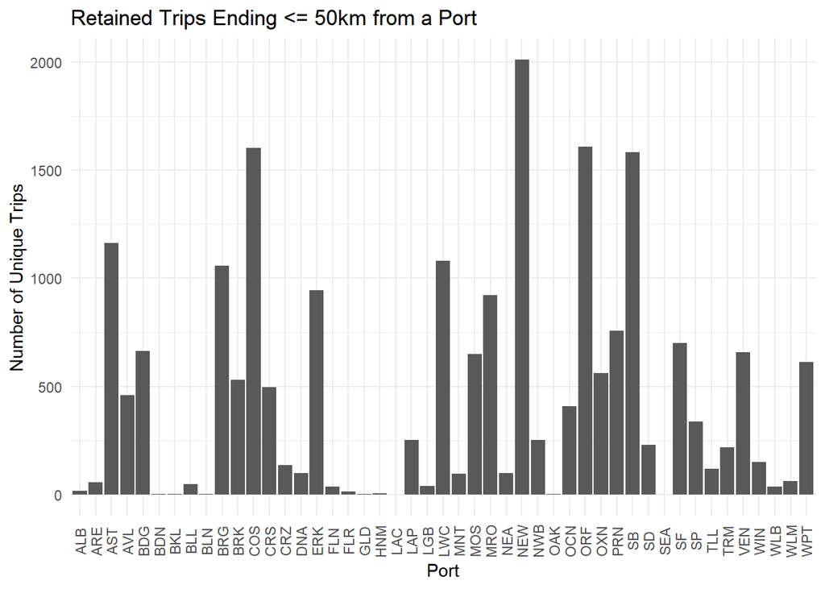

```r
retained_trips_plot <- trips_to_keep %>%
  select(Rec_ID, pacfin_port_code) %>%
  distinct() %>%
  ggplot(aes(x=pacfin_port_code)) +
  geom_bar() +
  labs(x="Port",y="Number of Unique Trips",title="Retained Trips Ending <= 50km from a Port")+
  theme_minimal()+
  theme(axis.text.x = element_text(angle=90,vjust=0.5))
retained_trips_plot
```

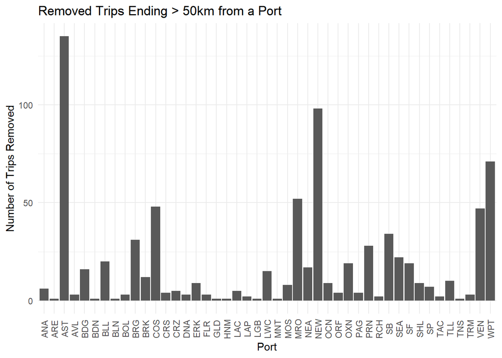

```r
trips_removed_plot <- trips_to_remove %>%
  select(Rec_ID, pacfin_port_code) %>%
  distinct() %>%
  ggplot(aes(x=pacfin_port_code)) +
  geom_bar() +
  labs(x="Port",y="Number of Trips Removed",title="Removed Trips Ending > 50km from a Port")+
  theme_minimal()+
  theme(axis.text.x = element_text(angle=90,vjust=0.5))
trips_removed_plot
```

Sort the VMS and fish ticket data by the output of this filtering exercise.

```r
keeps <- trips_to_keep %>%
  select(Rec_ID,keep_remove) %>%
  distinct()
removes <- trips_to_remove %>%
  select(Rec_ID,keep_remove) %>%
  distinct()
keeps_removes <- bind_rows(keeps,removes)

vms_keeps <- vms %>%
  left_join(keeps_removes,by='Rec_ID') %>%
  filter(keep_remove=='keep')

vms_removes <- vms %>%
  left_join(keeps_removes,by='Rec_ID') %>%
  filter(keep_remove=='remove')
```

## Save Results

### Write out VMS data that was removed

```r
write_rds(x=vms_removes, here::here('data','processed','matched',paste0(process_year,'matched_far_from_port.rds')))
write_rds(x=vms_keeps, here::here('data','processed','matched',paste0(process_year,'matched_port_dist_filter.rds')))
```

```r
x<-proc.time()-alltime
```

**So far, this pipeline for 2012 VMS data has taken 9.37 minutes to run.**